# 第2回 線形回帰で学ぶ汎化性能とリークの再現

# 5. 谷底を式一発で求める

## もっと細かくすれば？

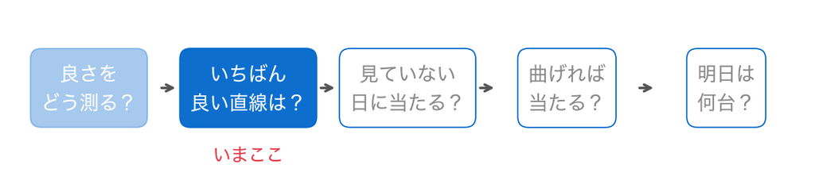

- 1ずつ、0.1ずつと細かくするほど、試す数が爆発的に増える。一発で谷底へ行けないか

## 谷底への道は2つ

5節 ① 式一発で求める●○○○○○○○

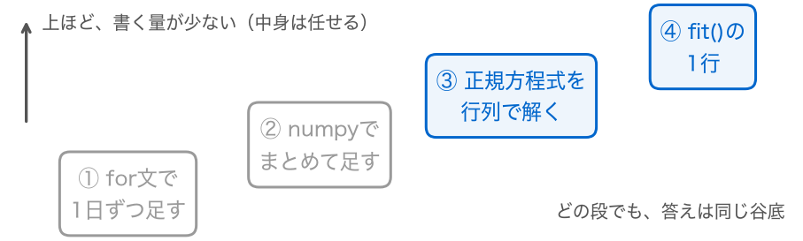

- 式で解く道（③）と、`fit()`に任せる道（④）。着く谷底は同じ
- 今日は一度だけ、式の道を通る

## 谷底では傾きが0

5節 ① 式一発で求める●●○○○○○○

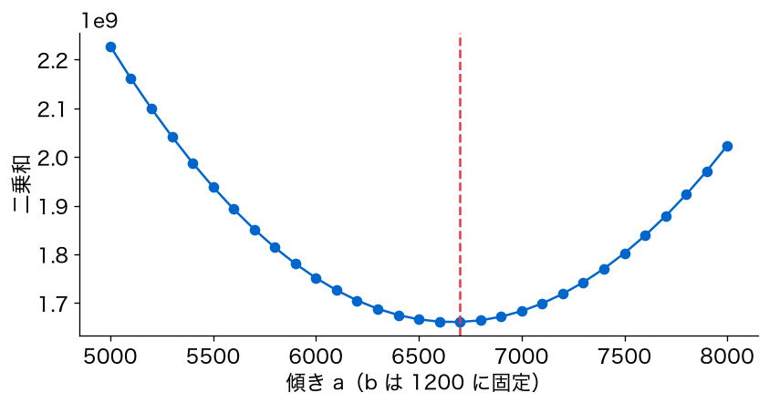

- 谷底では、aやbを少し動かしても二乗和は変わらない。つまり、どちらで微分しても0

## aとbで微分して0とおく

5節 ① 式一発で求める●●●○○○○○

$$\frac{\partial S}{\partial a} = \sum_{i=1}^{731} -2\,x_i\,\bigl(y_i - a\,x_i - b\bigr) = 0$$

$$\frac{\partial S}{\partial b} = \sum_{i=1}^{731} -2\,\bigl(y_i - a\,x_i - b\bigr) = 0$$

- $\partial$は、ほかの文字を止めて微分する、という印

## 2本の式に整理する

5節 ① 式一発で求める●●●●○○○○

$$\begin{aligned}
n\,b + \Bigl(\sum_i x_i\Bigr)\,a &= \sum_i y_i \\
\Bigl(\sum_i x_i\Bigr)\,b + \Bigl(\sum_i x_i^2\Bigr)\,a &= \sum_i x_i\,y_i
\end{aligned}$$

- $-2$で割って、aとbを含む項を左に集めた（$n = 731$）
- 知りたいのはaとbの2つ。式も2本。連立方程式として解ける

## 行列で書く

5節 ① 式一発で求める●●●●●○○○

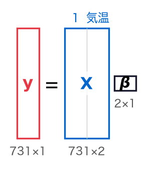

- $\mathbf{X}$は1の列と気温の列の表、$\boldsymbol{\beta} = (b, a)^\top$。予測$\mathbf{X}\boldsymbol{\beta}$で731日ぶんが出る

## 2本の式は正規方程式

5節 ① 式一発で求める●●●●●●○○

$$\underbrace{\begin{pmatrix} n & \sum_i x_i \\ \sum_i x_i & \sum_i x_i^2 \end{pmatrix}}_{\mathbf{X}^\top\mathbf{X}}
\begin{pmatrix} b \\ a \end{pmatrix}
=
\underbrace{\begin{pmatrix} \sum_i y_i \\ \sum_i x_i\,y_i \end{pmatrix}}_{\mathbf{X}^\top\mathbf{y}}$$

- 書き下すと、さっきの2本の式そのもの。これを$\mathbf{X}^\top\mathbf{X}\boldsymbol{\beta} = \mathbf{X}^\top\mathbf{y}$（正規方程式）と書く

## 答えは1行の式

5節 ① 式一発で求める●●●●●●●○

$$\hat{\boldsymbol{\beta}} = \bigl(\mathbf{X}^\top\mathbf{X}\bigr)^{-1}\mathbf{X}^\top\mathbf{y}$$

- $(\cdot)^{-1}$は逆行列。掛けると1にあたる行列（単位行列）になる行列
- $\mathbf{X}$の列が何本になっても、同じ式で谷底が出る

## これが最小二乗法

5節 ① 式一発で求める●●●●●●●●

- 外れの二乗和を最小にして、係数を決める
- このやり方を、最小二乗法と呼ぶ

## お手本：正規方程式をコードにする

5節 ② コードに落とす●○○○○○○

```python
X1 = np.column_stack([np.ones(len(x)), x])  # 1の列と、気温の列
A = X1.T @ X1                 # XᵀX
c = X1.T @ y                  # Xᵀy
beta = np.linalg.inv(A) @ c   # (XᵀX)⁻¹ Xᵀy
b_best, a_best = beta         # 切片と傾き
print(beta)
```

- 役割：正規方程式を、記号と1対1でコードにする

## 記号とコードの対応

5節 ② コードに落とす●●○○○○○

```python
A = X1.T @ X1                 # XᵀX
beta = np.linalg.inv(A) @ c   # (XᵀX)⁻¹ Xᵀy
```

- 転置$\mathbf{X}^\top$は`X1.T`、行列の積は`@`
- 逆行列$(\cdot)^{-1}$は`np.linalg.inv`

## 1の列をどう作る？

5節 ② コードに落とす●●●○○○○

```python
X1 = np.column_stack([np.ones(len(x)), x])  # 1の列と、気温の列
```

- `np.ones(731)`は、1が731個並んだ配列
- `np.column_stack`は、配列を列として横に並べ、表（行列）にする

## 式一発の谷底

5節 ② コードに落とす●●●●○○○

```
[1214.64211903 6640.70999855]
```

- b=1214.64、a=6640.71。TODO②の（6650, 1210）のすぐ近くが、正確な谷底

## fit()の中身も同じ谷底

5節 ② コードに落とす●●●●●○○

```python
model_temp = LinearRegression()
model_temp.fit(df[['気温']], y)
print(model_temp.coef_[0])           # 傾き a
print(model_temp.intercept_)         # 切片 b
```

- `LinearRegression()`で式の入れ物を作り、`fit`で学ばせる
- `coef_`（傾き）と`intercept_`（切片）で、結果を見る

## 二重のかっこは表の形

5節 ② コードに落とす●●●●●●○

```python
model_temp.fit(df[['気温']], y)
```

- 外の`[ ]`は列を選ぶかっこ。中の`['気温']`は列名の並び（リスト）
- 1列でも、表の形のまま取り出せる。`fit`は手がかりを表の形で受け取る

## fit() と一致

5節 ② コードに落とす●●●●●●●

```
6640.709998548634
1214.6421190294031
```

- `fit()`の1行の中身は、いま自分で書いた正規方程式の計算と同じ谷底

## R²：どれだけ減らせたか

5節 ③ R²で測る●○○○○○○

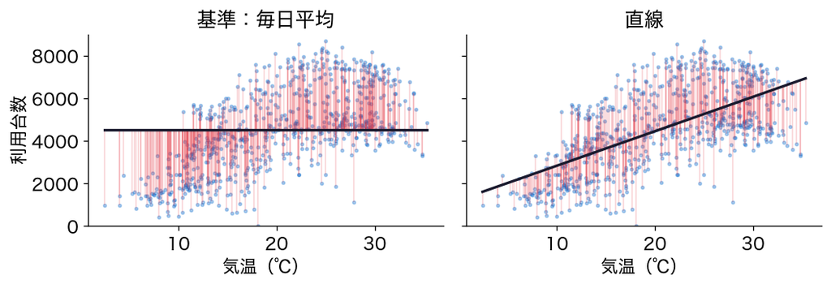

- 左の基準（毎日平均）の二乗和を、右の直線で何割減らせたかがR²。1に近いほどよい

## R²を式で書く

5節 ③ R²で測る●●○○○○○

$$R^2 = 1 - \frac{\sum_i (y_i - \hat{y}_i)^2}{\sum_i (y_i - \bar{y})^2}$$

- 分子は直線の二乗和、分母は毎日平均$\bar{y}$と答えたときの二乗和
- 直線が平均より外れれば、分数が1を超え、R²はマイナスになる

## 変えてみる：R²を自分で

5節 ③ R²で測る●●●○○○○

```python
pred_line = a_best * x + b_best
sse_line = ((y - pred_line) ** 2).sum()      # 直線の二乗和
sst = ((y - y.mean()) ** 2).sum()            # 基準の二乗和
print(1 - sse_line / sst)                    # R²
print(model_temp.score(df[['気温']], y))     # 答え合わせ
```

- `y.mean()`は、配列の平均を出すメソッド
- `score`は、渡したデータでのR²を返す

## R²は0.394

5節 ③ R²で測る●●●●○○○

```
0.3937487313729241
0.3937487313729241
```

- 基準の二乗和のうち、約4割を気温の直線で減らせた

## 平均の段と比べると？

5節 ③ R²で測る●●●●●○○

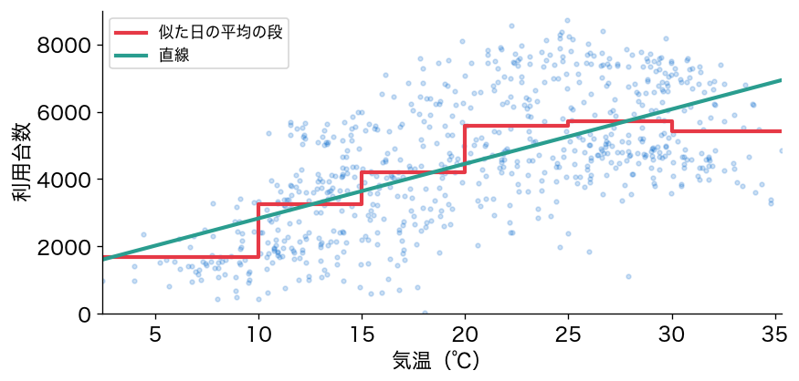

- 気温帯だけで分けた平均の段のR²は0.439。直線（0.394）より少し上

## 直線は右端を外す

5節 ③ R²で測る●●●●●●○

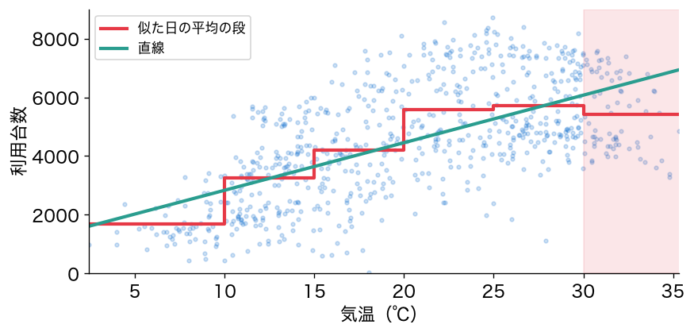

- 暑すぎると頭打ち。まっすぐな直線は、右端で多く見積もる

## それでも直線には良さがある

5節 ③ R²で測る●●●●●●●

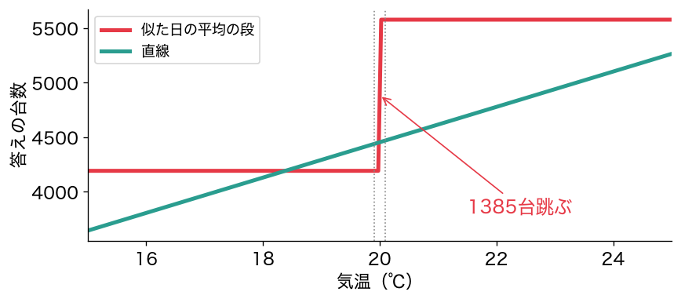

- 段は20℃の境目で跳ぶ。直線は跳ばず、どの気温にもなめらかに答える

## 変えてみる：手がかりを増やす

5節 ④ 列を増やす●○○○○○○○○

```python
model_ty = LinearRegression()
model_ty.fit(df[['気温', '年']], y)
print(model_ty.coef_, model_ty.intercept_)
print(model_ty.score(df[['気温', '年']], y))
```

- $\hat{y}_i = a_1 x_{i1} + a_2 x_{i2} + b$（$x_{i2}$は年）。列を並べるだけで重回帰になる

## 気温と年でR²は0.68

5節 ④ 列を増やす●●○○○○○○○

```
[6369.64490081 2083.23997526] 305.8787327748878
0.6825991406100751
```

- 各列に掛かる数（直線の傾きaにあたる数）を、係数と呼ぶ

## 列を11本に増やしても

5節 ④ 列を増やす●●●○○○○○○

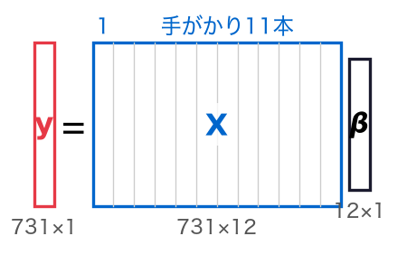

- 変わるのは$\mathbf{X}$の列の数だけ。正規方程式のコードは、そのまま使える

## 変えてみる：11本の列の表

5節 ④ 列を増やす●●●●○○○○○

```python
cols = ['季節', '年', '月', '祝日', '曜日', '平日',
        '天気', '気温', '体感気温', '湿度', '風速']
X11 = np.column_stack([np.ones(len(y)), df[cols].values])
print(X11.shape)
```

- 1の列に、11本の列を並べる。`df[cols].values`で、11列をまとめて配列にする

## TODO③：11本の列で解く

5節 ④ 列を増やす●●●●●○○○○

```python
# TODO: X11 で正規方程式を作り、β を求めて表示する
# ヒント: お手本の X1 を X11 に変え、最後に print する
...
```

- 出てくる係数は12個（切片1個と、11本の列の係数）

## やってみよう：5節とTODO③

5節 ④ 列を増やす●●●●●●○○○

- 5節のお手本と「変えてみる」のセルを実行し、同じ谷底が出るか確かめる
- TODO③：11本の列で、正規方程式を解く

動画の人は、ここで一時停止。

## 答え合わせ：TODO③

5節 ④ 列を増やす●●●●●●●○○

```
(731, 12)
[ 1469.     509.78  2040.7    -38.98  -518.99    69.06   120.36  -610.99
  2028.92  3573.27 -1018.86 -2557.57]
```

- 731行×12列。12個の係数が出る。先頭が切片

## 変えてみる：同じことを1行で

5節 ④ 列を増やす●●●●●●●●○

```python
model11 = LinearRegression().fit(df[cols], y)
print(round(model11.intercept_, 2))
print(model11.coef_.round(2))
```

- 1の列は、`LinearRegression`が自分で足してくれる

## 自分で解いた12個と同じ

5節 ④ 列を増やす●●●●●●●●●

```
1469.0
[  509.78  2040.7    -38.98  -518.99    69.06   120.36  -610.99  2028.92
  3573.27 -1018.86 -2557.57]
```

- 正規方程式を自分で書いた答えと、1行の答えが一致する。これがライブラリの便利さ

## 普段はどちらを使う？

5節 ⑤ 式は何のため●○○○

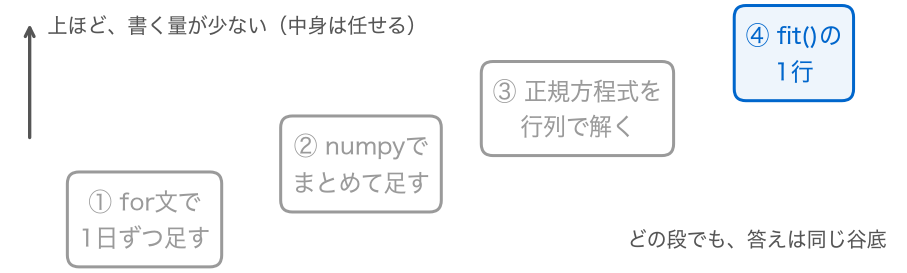

- データ解析なら、`fit()`の1行で十分
- 6節から先は、`fit()`で進む

## では式の道は何のため？

5節 ⑤ 式は何のため●●○○

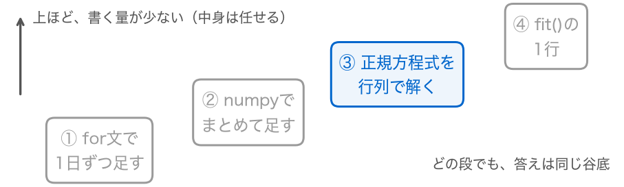

- 今日やったのは、式の記号を、コードに1対1で写すこと
- これができると、何ができるようになるか？

## 式とコードを行き来できる

5節 ⑤ 式は何のため●●●○

- 結果がおかしいとき、`fit()`の中で何が起きたかを疑える
- 教科書や論文の式を読んで、コードで確かめられる

## 手法を作る人はみんな書いている

5節 ⑤ 式は何のため●●●●

- `fit()`の中身も、誰かが式からこう書いたもの
- 新しい手法やライブラリを作る人は、この対応づけを毎回やっている
- 使うだけなら`fit()`。作るなら、式からコードへ

# 6. 自己採点は甘くないか

## まだ見ていない日に当たる？

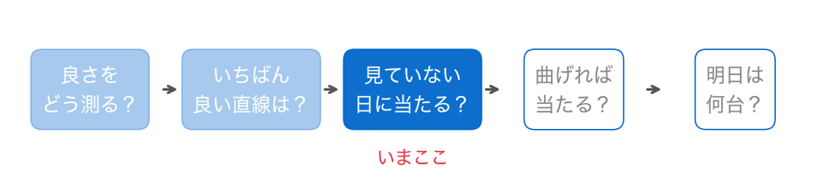

- ここまでのR²は、式を作るのに使った731日で測っていた

## 訓練データとテストデータ

6節 ① 分けて測る●○○○○○

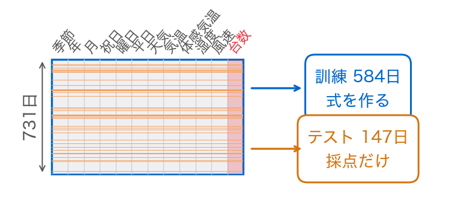

- 訓練（過去問）で式を作り、テスト（本番）で採点する。テストでの当たり具合が汎化性能

## 平均の段で試すと？

6節 ① 分けて測る●●○○○○

```
['気温帯', '年']
  作った日          : 766 台
  答えを出せない日  : 0 日
  答えを出せた日    : 773 台
['月', '年', '天気', '曜日']
  作った日          : 393 台
  答えを出せない日  : 45 日
  答えを出せた日    : 665 台
```

- 訓練584日で作り直した気温帯×年の段は、作った日766台、見ていない日773台。ほぼ同じ

## 考えてみよう：細かい段は？

6節 ① 分けて測る●●●○○○

- 月×年×天気×曜日の細かい段は、作った日では393台しか外れない
- まだ見ていない147日で試すと、何が起きそうか？

考える時間。動画の人は、ここで一時停止して、予想をノートに書く。

## 45日には答えがない

6節 ① 分けて測る●●●●○○

```
['気温帯', '年']
  作った日          : 766 台
  答えを出せない日  : 0 日
  答えを出せた日    : 773 台
['月', '年', '天気', '曜日']
  作った日          : 393 台
  答えを出せない日  : 45 日
  答えを出せた日    : 665 台
```

- テスト147日のうち45日は、訓練に同じ組み合わせの日がない
- その日には、段の答えそのものが出せない

## 102日でも665台外れる

6節 ① 分けて測る●●●●●○

```
['気温帯', '年']
  作った日          : 766 台
  答えを出せない日  : 0 日
  答えを出せた日    : 773 台
['月', '年', '天気', '曜日']
  作った日          : 393 台
  答えを出せない日  : 45 日
  答えを出せた日    : 665 台
```

- 作った日の393台より、ずっと外れる

## 覚えていただけだった

6節 ① 分けて測る●●●●●●

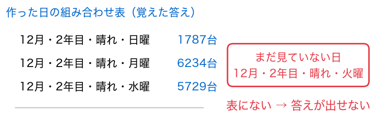

- 細かい段は、作った日の組み合わせの台数を覚えていただけ
- 表にない組み合わせの日には、答えそのものがない

## では直線の式は？

6節 ② 直線で試す●○○○

- 11本の列を手がかりにした直線の式を、訓練だけで作る
- テストのR²が訓練と同じくらいなら、覚えすぎていない

## お手本：訓練とテストに分ける

6節 ② 直線で試す●●○○

```python
cols = ['季節', '年', '月', '祝日', '曜日', '平日',
        '天気', '気温', '体感気温', '湿度', '風速']
X = df[cols].values
X_tr, X_te, y_tr, y_te = train_test_split(X, y, test_size=0.2,
                                          random_state=42)
print(len(X_tr), len(X_te))
```

- 役割：11本の列を手がかりに、訓練8割・テスト2割に分ける

## random_stateは混ぜ方の番号

6節 ② 直線で試す●●●○

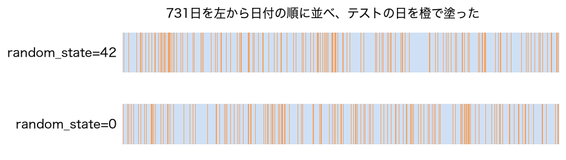

- 行を混ぜてから分ける。`random_state`の番号で、混ぜ方が決まる
- 番号を固定すれば、何度やっても同じ分け方になる

## 訓練584日とテスト147日

6節 ② 直線で試す●●●●

```
584 147
```

- 731日を、584日と147日に分けた

## TODO④：訓練とテストのR²

6節 ③ 確かめる●○○○○

```python
# TODO: 訓練データだけで fit し、訓練の R² とテストの R² を表示する
...
```

- `LinearRegression().fit(X_tr, y_tr)` → `score`を2回

## やってみよう：6節とTODO④

6節 ③ 確かめる●●○○○

- 6節のお手本のセルを実行し、同じ日数を確かめる
- TODO④：訓練だけで学び、訓練とテストのR²を比べる

動画の人は、ここで一時停止。

## 答え合わせ：TODO④

6節 ③ 確かめる●●●○○

```
訓練 R²  : 0.7910851850465888
テスト R²: 0.8276670090367212
```

- 訓練0.791、テスト0.828。ほぼ同じ

## ということは？

6節 ③ 確かめる●●●●○

- この直線の式は、作った日を覚えすぎていない
- まだ見ていない日にも、同じくらい当たる。汎化性能は、訓練並み

## テストのほうが高いのはなぜ？

6節 ③ 確かめる●●●●●

- たまたま、当てやすい日がテストに入った
- 1回の分け方の値は、運で上下するかもしれない（課題の応用①で確かめる）

## 考えてみよう：完璧すぎる式

6節 ④ リークを再現する●○○○○

- 11本の列に、ある2列を足すと、まだ見ていないテストのR²が1.0になる
- どの日もぴったり当たる。どこがおかしいか？ 導入で見た表を思い出す

考える時間。動画の人は、ここで一時停止して、予想をノートに書く。

## 変えてみる：一般客と会員を足す

6節 ④ リークを再現する●●○○○

```python
cols_leak = cols + ['一般客', '会員']
X_leak = df[cols_leak].values
XL_tr, XL_te, yL_tr, yL_te = train_test_split(
    X_leak, y, test_size=0.2, random_state=42)
model_leak = LinearRegression().fit(XL_tr, yL_tr)
print('テスト R²:', model_leak.score(XL_te, yL_te))
```

- `cols + [...]`で、6節の列のリストに2列をつなぐ。分け方も同じ

## テストのR²は1.0

6節 ④ リークを再現する●●●○○

```
テスト R²: 1.0
```

- まだ見ていないテストでも、どの日もぴったり当たった

## 答えが手がかりに漏れていた

6節 ④ リークを再現する●●●●○

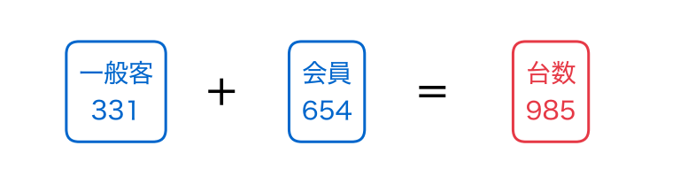

- 係数を1と1、ほかを0にすれば外れは0。これをリーク（情報の漏れ）と呼ぶ
- 訓練とテストに分けても、両方に同じ漏れがあるので見抜けない

## 明日には使えない

6節 ④ リークを再現する●●●●●

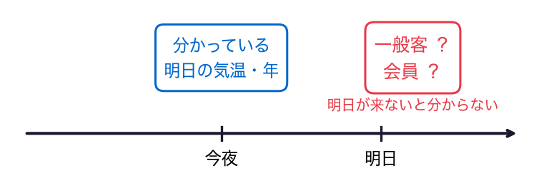

- テストの成績が良すぎるときは、まずリークを疑う

# 7. 式を曲げすぎると？

## 覚えすぎない直線を曲げると？

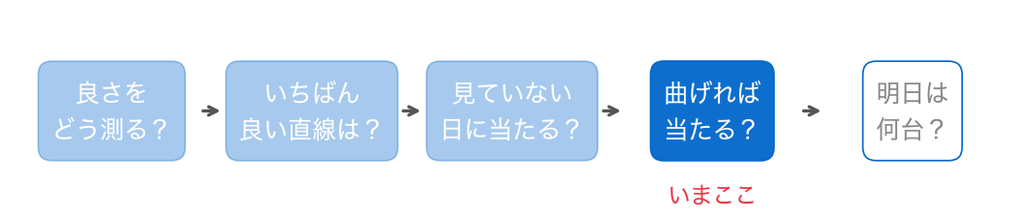

- 直線は、暑い日の頭打ちを外した。曲げれば、もっと当たる？

## 次数を上げると

7節 ① 曲線の作り方●○○○○

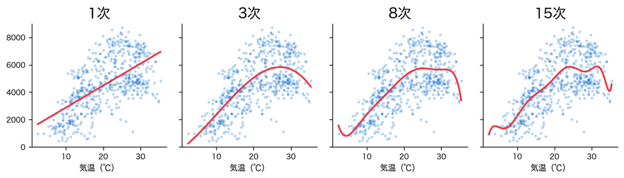

- $\hat{y} = b + a_1 x + a_2 x^2 + \cdots + a_d x^d$。$d$が次数。曲げるほど点に近づく

## 2乗・3乗の列を作ってつなぐ

7節 ① 曲線の作り方●●○○○

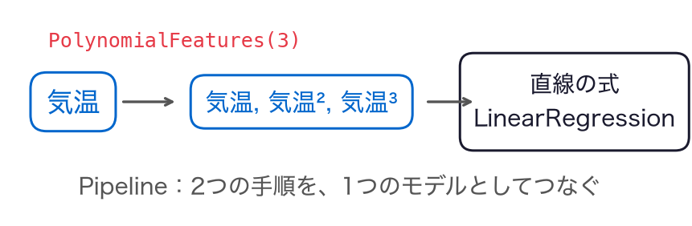

- 気温の列から2乗・3乗の列を作り、それを直線の式に入れる

## 1本の列を表の形のまま取り出す

7節 ① 曲線の作り方●●●○○

```python
x1_tr = X_tr[:, [7]]    # 8本目の列（気温）だけ
```

- `:`はすべての行、`[7]`は8本目の列（番号は0から）
- `[7]`とかっこで囲むと、1列の表の形のまま取り出せる。`fit`は表の形を求める

## お手本：3次の曲線

7節 ① 曲線の作り方●●●●○

```python
x1_tr = X_tr[:, [7]]    # 8本目の列（気温）だけ
x1_te = X_te[:, [7]]
model3 = Pipeline([('poly', PolynomialFeatures(3)),
                   ('lr', LinearRegression())])
model3.fit(x1_tr, y_tr)
print(model3.score(x1_tr, y_tr), model3.score(x1_te, y_te))
```

- `PolynomialFeatures(3)`が2乗・3乗の列を作り、`Pipeline`で直線の式につなぐ

## 3次は訓練0.47・テスト0.41

7節 ① 曲線の作り方●●●●●

```
0.4720415505498843 0.4137499258721813
```

- 左が訓練のR²、右がテストのR²（気温1本だけの式）

## TODO⑤：次数を変えて並べる

7節 ② 次数を比べる●○○○○○

```python
# TODO: for deg in [1, 3, 8, 15]: として、次数ごとの
#       訓練 R² とテスト R² を表示する
...
```

- お手本の`3`を`deg`に変え、`for`文の中に入れる

## やってみよう：7節とTODO⑤

7節 ② 次数を比べる●●○○○○

- 7節のお手本のセルを実行し、同じR²を確かめる
- TODO⑤：次数を1・3・8・15と変えて、訓練とテストのR²を並べる

動画の人は、ここで一時停止。

## 答え合わせ：TODO⑤

7節 ② 次数を比べる●●●○○○

```
1 次: 0.3881 0.4037
3 次: 0.472 0.4137
8 次: 0.4757 0.4079
15 次: 0.4812 0.4073
```

- 左が訓練のR²、右がテストのR²

## 訓練のR²は上がり続ける

7節 ② 次数を比べる●●●●○○

```
1 次: 0.3881 0.4037
3 次: 0.472 0.4137
8 次: 0.4757 0.4079
15 次: 0.4812 0.4073
```

- 0.388 → 0.472 → 0.476 → 0.481。曲げるほど、訓練には当たる

## テストのR²は？

7節 ② 次数を比べる●●●●●○

```
1 次: 0.3881 0.4037
3 次: 0.472 0.4137
8 次: 0.4757 0.4079
15 次: 0.4812 0.4073
```

- 0.404 → 0.414 → 0.408 → 0.407。曲げても、ほぼ横ばい

## 584日あれば曲げても崩れない

7節 ② 次数を比べる●●●●●●

- 訓練が584日あると、曲線は1日1日の偶然の揺れに振り回されにくい
- だから曲げすぎても、テストのR²はほとんど下がらない
- では、データが少なかったら？

## 考えてみよう：20日だけなら？

7節 ③ 20日だけで学ぶ●○○○○○○

- 訓練を584日から20日に減らし、テストは同じ147日のまま、1次・3次・8次と曲げる
- 訓練のR²とテストのR²は、それぞれどう動くと思うか？

考える時間。動画の人は、ここで一時停止して、予想をノートに書く。

## 変えてみる：20日だけで学ぶ

7節 ③ 20日だけで学ぶ●●○○○○○

```python
x20 = x1_tr[:20]     # 訓練の最初の20日だけ
y20 = y_tr[:20]
for deg in [1, 3, 8]:
    m = Pipeline([('poly', PolynomialFeatures(deg)),
                  ('lr', LinearRegression())])
    m.fit(x20, y20)
    print(deg, '次:', round(m.score(x20, y20), 3),
          round(m.score(x1_te, y_te), 3))
```

- `[:20]`で、訓練の最初の20日を取り出す。1・3・8次で、訓練とテストのR²

## 訓練は上がる

7節 ③ 20日だけで学ぶ●●●○○○○

```
1 次: 0.228 0.362
3 次: 0.444 -0.288
8 次: 0.499 -28.353
```

- 左の訓練のR²は0.228 → 0.444 → 0.499。曲げるほど上がる

## テストはマイナスに

7節 ③ 20日だけで学ぶ●●●●○○○

```
1 次: 0.228 0.362
3 次: 0.444 -0.288
8 次: 0.499 -28.353
```

- 右のテストのR²は0.362 → −0.288 → −28.353
- マイナスは、毎日平均と答えるより悪いということ

## 8次の曲線は点のない所で暴れる

7節 ③ 20日だけで学ぶ●●●●●○○

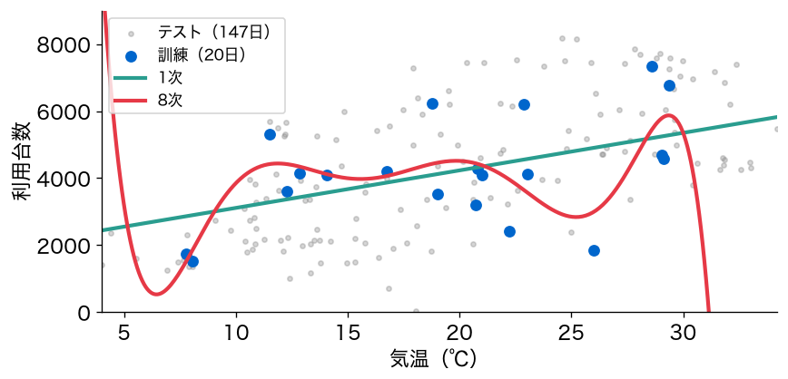

- 青い20日に合わせて曲がり、20日の外（8℃未満・29℃超）で大きく外れる

## これが過学習

7節 ③ 20日だけで学ぶ●●●●●●○

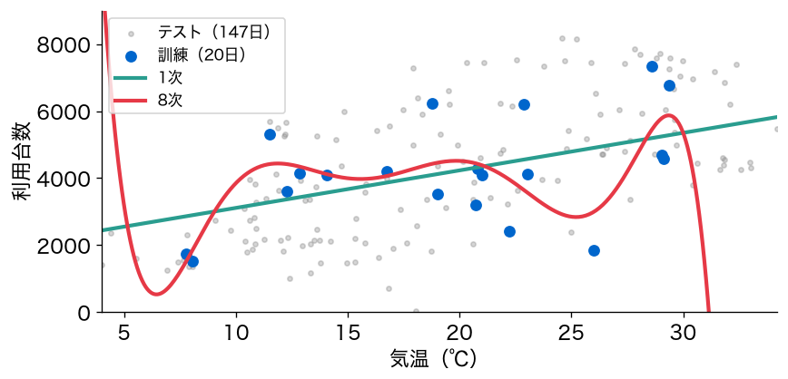

- 曲げすぎた式は、訓練データの偶然の揺れまで覚える
- データが少ないほど、はっきり出る

## やってみよう：20日の例

7節 ③ 20日だけで学ぶ●●●●●●●

- 「変えてみる：20日だけで学ぶ」のセルと、その下の図のセルを実行する
- 同じR²と図が出るか確かめる

動画の人は、ここで一時停止。

# 8. 明日は何台？

## では明日は何台？

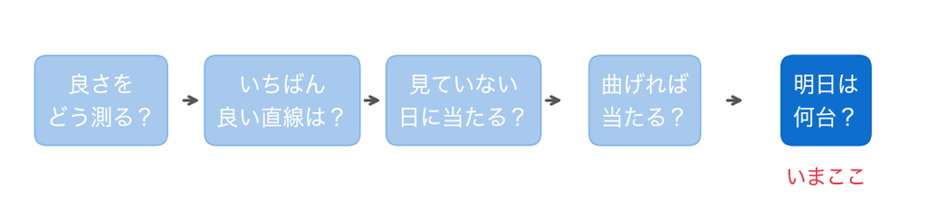

- 明日の湿度や風速は、まだ分からない。明日に答えるのは、気温と年の式にする

## お手本：気温と年の式を測る

8節 ① 明日の台数●○○○○○

```python
Xty = df[['気温', '年']].values
Xty_tr, Xty_te, yty_tr, yty_te = train_test_split(
    Xty, y, test_size=0.2, random_state=42)
model_ty = LinearRegression().fit(Xty_tr, yty_tr)
print('訓練 R²  :', model_ty.score(Xty_tr, yty_tr))
print('テスト R²:', model_ty.score(Xty_te, yty_te))
```

- 6節のお手本とTODO④を、2本の列の`Xty`で。分け方も6節と同じ

## 2本の列ならテストのR²は0.71

8節 ① 明日の台数●●○○○○

```
訓練 R²  : 0.6727204673783596
テスト R²: 0.7128404660904721
```

- 11本の列の0.828より低い。その代わり、明日に使える式になった

## 変えてみる：外れ幅と明日の予測

8節 ① 明日の台数●●●○○○

```python
err_tr = np.abs(yty_tr - model_ty.predict(Xty_tr)).mean()
err_te = np.abs(yty_te - model_ty.predict(Xty_te)).mean()
print('作った日の外れ幅  :', round(err_tr), '台')
print('まだ見ていない日  :', round(err_te), '台')
pred_t = model_ty.predict([[27 / 41, 1]])[0]     # 27℃・2年目
print('明日（27℃・2年目）:', round(pred_t), '台')
```

- 外れ幅の平均 $\frac{1}{n}\sum_i |y_i - \hat{y}_i|$ を、作った日と見ていない日で測る

## predictは予測を返す

8節 ① 明日の台数●●●●○○

```python
pred_t = model_ty.predict([[27 / 41, 1]])[0]     # 27℃・2年目
```

- `predict`に手がかりの表を渡すと、予測が返る。`[[ ]]`は1行の表
- 式に代入するだけ：$\hat{y} = a_1 \cdot \frac{27}{41} + a_2 \cdot 1 + b$
- 予測は並びで返るので、`[0]`で1つ目を取り出す

## 答え：およそ6600台

8節 ① 明日の台数●●●●●○

```
作った日の外れ幅  : 859 台
まだ見ていない日  : 837 台
明日（27℃・2年目）: 6565 台
```

およそ6600台。まだ見ていない日での外れ幅は、平均840台くらい。

## 2年目の直線の27℃の点

8節 ① 明日の台数●●●●●●

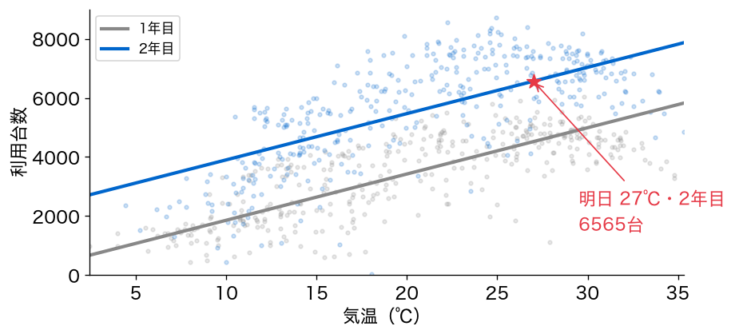

- 年ごとに1本ずつ、平行な直線。明日は、2年目の直線の27℃の高さ

## やってみよう：8節

8節 ② 確かめる●

- 8節のお手本と「変えてみる」のセルを実行し、同じ答えが出るか確かめる

動画の人は、ここで一時停止。

## 似た日の平均より低いのは？

8節 ③ 似た日の平均と比べる●○○

- 似た日の平均（25〜30℃・2年目・晴れの54日）なら、およそ7200台。今日は6600台
- なぜ、今日のほうが低いのか？

## 天気で半分と直線の形で半分

8節 ③ 似た日の平均と比べる●●○

```
晴れの54日      : 7198 台
天気を混ぜた84日: 6843 台
今日の直線      : 6565 台
```

- 似た日の平均は、晴れの54日だけ。今日の式は、晴れも雨も混ぜた見積もり
- 差の633台のうち355台は天気、残りの278台は直線が頭打ちをなぞれないぶん

## 外れ幅は同じテストで比べる

8節 ③ 似た日の平均と比べる●●●

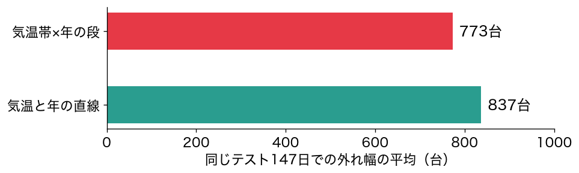

- 54日の中の外れ幅「500台前後」は、作った日の値。同じテストなら、直線は段より少し外れる

## まだ言えないこと①：分け方の運

8節 ④ まだ言えないこと●○○○

- テストのR²（6節の0.828、8節の0.713）は、`random_state=42`で分けた1回の値
- 分け方を変えたら、どれくらい動くのか？

## まだ言えないこと②：データの汚れ

8節 ④ まだ言えないこと●●○○

- 今日のデータは、欠けた値も文字の列もない、きれいなデータ
- 実務のデータは、そうはいかない

## まだ言えないこと③：物差し

8節 ④ まだ言えないこと●●●○

- R²も二乗和を使うので、大外れを重く見ている
- 外れ幅の平均は、どの外れも同じ重さ。どちらで測るかは場面しだい

## まだ言えないこと④：係数の読み方

8節 ④ まだ言えないこと●●●●

- 5節の式の年の係数 約2083は「2年目は、同じ気温でも2083台多い」と読めるのか？

# まとめ

## 今日の道筋を振り返る

⑥ 振り返る●○○○

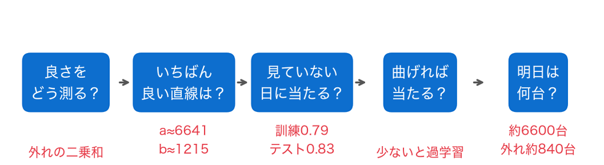

- 5つの小さな問いに答えて、式の実力と明日の台数にたどり着いた

## 今日の歩み

⑥ 振り返る●●○○

1日の計算 → 731日 → 総当たり → 式一発 → 分けて測る → リーク → 曲げすぎ → 明日の台数

## 今日持ち帰る1文

⑥ 振り返る●●●○

作るのに使ったデータの成績は信じない。まだ見ていないデータで測り、良すぎたら漏れを疑う。

## 今日の要点

⑥ 振り返る●●●●

- 二乗和を最小にする係数は、正規方程式$\hat{\boldsymbol{\beta}} = (\mathbf{X}^\top\mathbf{X})^{-1}\mathbf{X}^\top\mathbf{y}$で求まる
- 総当たり（`for`・`if`）、正規方程式（`@`・`.T`・`inv`）、`LinearRegression`の1行は同じ谷底
- 作るのに使ったデータの成績は甘い。訓練とテストに分けて測る（汎化性能）
- 答えの内訳を手がかりに入れると、テストでも完璧に当たる（リーク）
- 曲げすぎると過学習。データが少ないほど、はっきり出る

## 課題の出し方

⑦ このあと●○○○

- ノートの最後の「課題（提出）」に取り組む
- 応用②の答えと応用③の文章を、LACSに入力して提出（＝出席。期限なし）
- AIを使ってもよい。何を聞いて、どう直したかを1行書く

## 次回予告：データを整える

⑦ このあと●●○○

- 場面は、民泊の値付け
- 極端な値・欠けた値・文字の列・ばらばらの目盛りを、一つずつ整える

## 次回の問い

⑦ このあと●●●○

自分の部屋に、1泊いくらの値段を付ければいいか？

## このあと：課題へ

⑦ このあと●●●●

ノートの「課題（提出）」へ。分け方を5通りに変えて、テストのR²の揺れを測ります。